# Re-Analysis (simplified): bodyfat prediction

- Show All Code
- Hide All Code
- View Source

2024

Contrast-Bayes-Frequentist

STRATOS

R

Classification: confidential

Author

Affiliation

Mariana Nold

University of Jena, Institute of Sociology

Published

July 11, 2025

## 0.1 Preliminaries

This analysis report relates to SRe-API for the Analysis of bodyfat example (simplified).

## 0.2 Load libraries

```r
library("rstanarm")
library("projpred")
library("ggplot2")
library("loo")
library("bayesplot")
library("bayesrules")
library("DHARMa")
library("ggplot2")
library("dplyr")
library("tidyr")
library("patchwork")
library("posterior")
library("knitr")
library("kableExtra")
```

# 1 Model estimation

## 1.1 Load data

```r
load("../Datafiles/bodyfatdata.Rdata")
PPath <- "C:/Users/zo95yup/Documents/GitHub/Bayes_for_STRATOS/Task Bodyfat/"
```

## 1.2 Main data analysis

### 1.2.1 Define and fit reference model

```r
# Create the vector of predictor names
predictors <- c("Weight", "Height", "BMI", "Age",
  "Neck", "Chest", "Biceps", "Hips", "Waist",
  "Forearm", "MThigh", "Wrist",
  "Knee", "Ankle")

# Collapse the predictor names into a single string joined by +
rhs <- paste(predictors, collapse = " + ")

# Combine with the response variable to create a formula
rmf <- as.formula(paste("Fat ~", rhs))

# Print it to check
rmf

# Fit a Bayesian Gaussian regression model using stan_glm
ref_fit <- stan_glm(rmf, data = women, family = gaussian())
```

```r
draws <- as.matrix(ref_fit)
# This function returns Rhat and n_eff diagnostics for each model parameter.
# Use it to evaluate convergence and sampling efficiency in Bayesian regression.
# Recommended threshold: Rhat < 1.01 and n_eff_bulk and n_eff_tail > 100 per chain for # reliable inference. see: https://mc-stan.org/rstan/reference/Rhat.html


diagnostics <- summarise_draws(draws)
diagnostics_tbl <- diagnostics[, c("variable", "rhat", "ess_bulk" , "ess_tail")]

kable(diagnostics_tbl, digits = 3, caption = "MCMC diagnostics") %>%
  kable_styling(full_width = FALSE)
```

MCMC diagnostics

| variable | rhat | ess_bulk | ess_tail |
| --- | --- | --- | --- |
| (Intercept) | 1.000 | 2420.904 | 2611.515 |
| Weight | 1.001 | 2363.939 | 2686.906 |
| Height | 1.001 | 2362.978 | 2503.995 |
| BMI | 1.001 | 2371.307 | 2651.603 |
| Age | 1.000 | 5221.454 | 3146.830 |
| Neck | 1.000 | 4853.728 | 2745.055 |
| Chest | 1.000 | 5365.499 | 3146.010 |
| Biceps | 1.001 | 4639.283 | 3499.341 |
| Hips | 1.000 | 4855.745 | 2483.798 |
| Waist | 1.000 | 4786.262 | 3090.837 |
| Forearm | 1.000 | 4494.819 | 3449.872 |
| MThigh | 1.000 | 4390.502 | 2613.764 |
| Wrist | 1.000 | 4393.622 | 3053.098 |
| Knee | 1.000 | 4954.437 | 2768.295 |
| Ankle | 1.000 | 4646.618 | 2995.138 |
| sigma | 1.000 | 4390.875 | 2502.343 |

```r
prior_summary(ref_fit) # https://cran.r-project.org/web/packages/rstanarm/vignettes/priors.html
```

```
Priors for model 'ref_fit'
------
Intercept (after predictors centered)
  Specified prior:
    ~ normal(location = 22, scale = 2.5)
  Adjusted prior:
    ~ normal(location = 22, scale = 15)

Coefficients
  Specified prior:
    ~ normal(location = [0,0,0,...], scale = [2.5,2.5,2.5,...])
  Adjusted prior:
    ~ normal(location = [0,0,0,...], scale = [  1.77,246.96,  5.38,...])

Auxiliary (sigma)
  Specified prior:
    ~ exponential(rate = 1)
  Adjusted prior:
    ~ exponential(rate = 0.17)
------
See help('prior_summary.stanreg') for more details
```

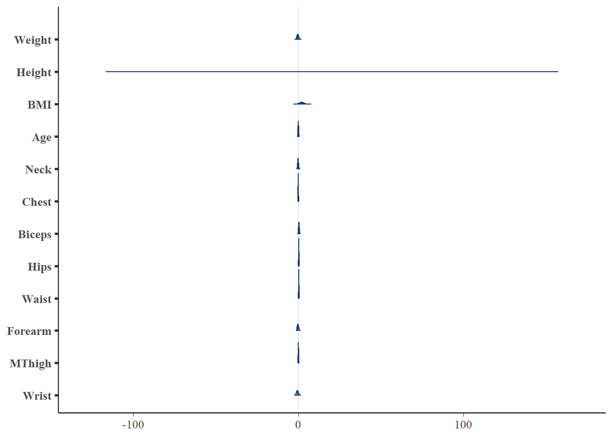

```r
mat_ref_fit <- as.matrix(ref_fit)
draws_ref_fit <- posterior::as_draws_matrix(mat_ref_fit)
mcmc_areas(mat_ref_fit[,2:13])
```

```r
summary_tbl_ref_fit <- summarise_draws(draws_ref_fit, mean, sd, median, ~quantile(.x, probs = c(0.05, 0.95)))
kable(summary_tbl_ref_fit, digits = 3, caption = "Posterior summary statistics")
```

Posterior summary statistics

| variable | mean | sd | median | 5% | 95% |
| --- | --- | --- | --- | --- | --- |
| (Intercept) | -59.121 | 58.991 | -58.034 | -156.383 | 35.803 |
| Weight | -0.401 | 0.495 | -0.398 | -1.220 | 0.383 |
| Height | 19.942 | 35.867 | 19.900 | -38.070 | 79.728 |
| BMI | 1.760 | 1.387 | 1.762 | -0.497 | 4.037 |
| Age | -0.035 | 0.175 | -0.032 | -0.326 | 0.246 |
| Neck | -0.181 | 0.265 | -0.177 | -0.618 | 0.255 |
| Chest | -0.067 | 0.092 | -0.067 | -0.217 | 0.084 |
| Biceps | 0.344 | 0.225 | 0.342 | -0.032 | 0.712 |
| Hips | 0.272 | 0.100 | 0.271 | 0.108 | 0.439 |
| Waist | 0.264 | 0.092 | 0.265 | 0.112 | 0.419 |
| Forearm | -0.281 | 0.389 | -0.281 | -0.909 | 0.362 |
| MThigh | 0.007 | 0.129 | 0.005 | -0.208 | 0.223 |
| Wrist | -0.604 | 0.534 | -0.607 | -1.467 | 0.279 |
| Knee | 0.511 | 0.213 | 0.510 | 0.160 | 0.859 |
| Ankle | -0.499 | 0.314 | -0.495 | -1.022 | 0.008 |
| sigma | 3.454 | 0.190 | 3.445 | 3.156 | 3.778 |

Investigate quality of the reference model:

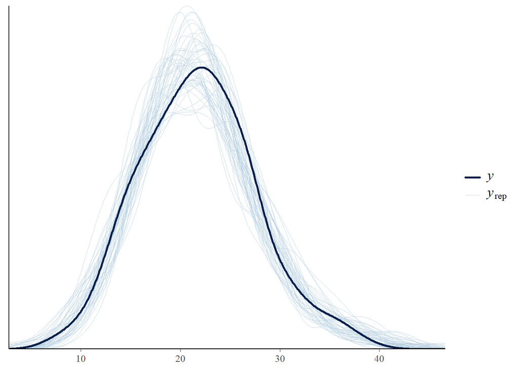

```r
pp_check(ref_fit)
```

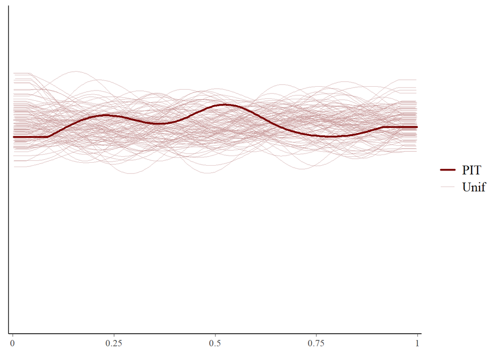

```r
y_rep_rmf <- posterior_predict(ref_fit)
loo_rmf <- loo(ref_fit , save_psis = TRUE, cores = 4)
psis1_rmf <- loo_rmf$psis_object
lw_rmf <- weights(psis1_rmf)
color_scheme_set("red")

ppc_loo_pit_overlay(y = women$Fat,yrep=y_rep_rmf,lw=lw_rmf)
```

```r
# Summarize the posterior distributions simple model
summary_rmf_cv <- prediction_summary_cv(model = ref_fit , data = women, k = 3)

# Print the summary simple model
print(summary_rmf_cv)
```

```
$folds
  fold      mae mae_scaled within_50 within_95
1    1 2.179959  0.5698993 0.5322581 0.9677419
2    2 2.161879  0.5774243 0.5245902 0.9672131
3    3 2.047498  0.5565123 0.5409836 0.9180328

$cv
       mae mae_scaled within_50 within_95
1 2.129779  0.5679453 0.5326106 0.9509959
```

The reference model passes the checks and therefore I decide to use this model, because it predicts well. In a next step I use the `projpred`-algorithms to find a simpler model that gives similar predictions as the reference model. In `projpred`, variable selection is performed by evaluating submodels of increasing size, starting from zero predictors up to a predefined maximum (`nterms_max`) in case of of **forward excursion.** When fixing the number of variables (which is not possible for L1 search), the best model of that size is chosen by projecting the reference model onto all candidate submodels and selecting the one with minimal expected Kullback-Leibler divergence (KLD)—this ensures the reduced model preserves the predictive distribution of the full model as closely as possible.

In the case of **L1-regularized search**, coefficients are estimated over a grid of penalization values using the reference model’s fit in place of the observed response. This produces a sequence of sparse models ranked by the order in which variables enter with non-zero coefficients as the penalty decreases. While computationally efficient, L1 search does not support fixing model size in advance, making it less flexible than forward search in that regard. Importantly, penalization is only used for variable ranking; submodels are later refit using projections without penalization.

To evaluate predictor stability, the search procedure is repeated across data subsets. **In this re-analysis,** **leave-one-out cross-validation (LOO)** **is used in combination with** **L1 search** **as the primary strategy (`LOO-L1`).** Additionally, 5-fold cross-validation is implemented to assess the **robustness** of variable selection and predictive performance. In cross-validation mode, selection is performed on training folds, and performance is evaluated on held-out test data. Results are also computed based on forward excursion, in combination with LOO-CV and 5-fold-CV.

Finally, output visualizations report the proportion of times each variable was selected. If `cumulate = FALSE`, proportions reflect selection at specific ranking positions. If `cumulate = TRUE`, they capture cumulative inclusion up to each rank, as annotated in the “CV ranking proportions matrix” plot.

Before inspecting the results, the primary search strategy was set to LOO-L1 (leave-one-out cross-validation with L1-regularized search), as this most closely aligns with the original SAP. To assess the robustness of predictor selection, forward selection and 5-fold cross-validation were additionally computed, not as alternatives, but to evaluate whether they yield different sets of selected variables, thus to access the internal robustness.

**Predictive Projections: Forward search, LOO (internal robustness)**

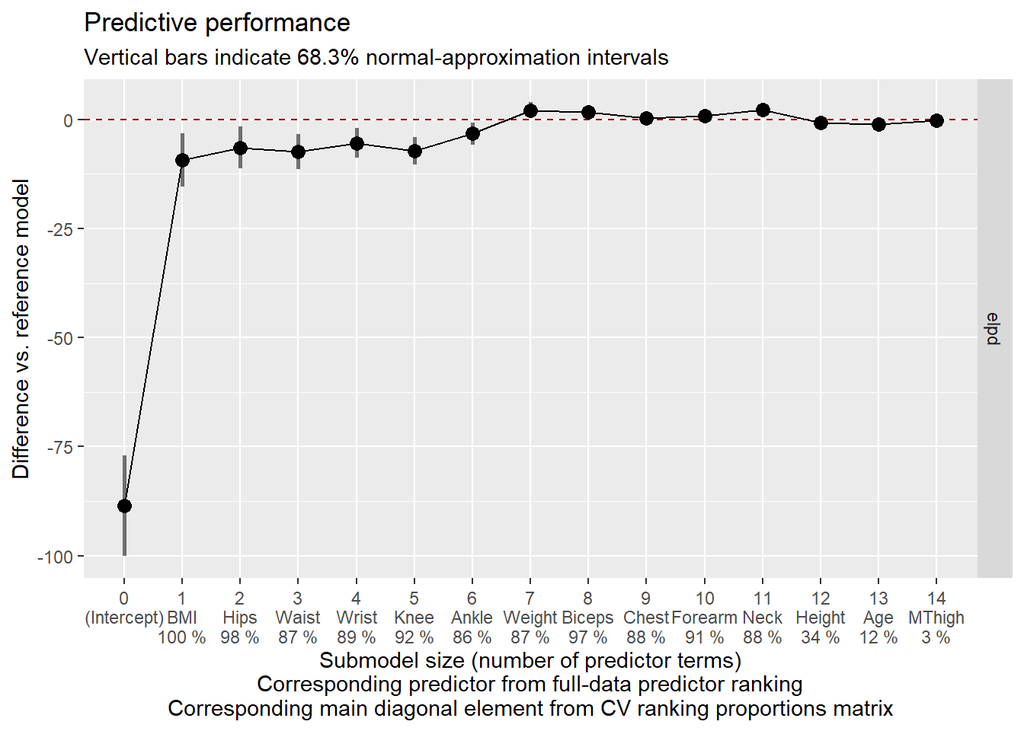

```r
set.seed(2341)
vs_cvf <- cv_varsel(object = ref_fit, method = 'forward', cv_method = 'loo', validate_search = TRUE, verbose = FALSE)

save(vs_cvf,file = file.path(PPath,"vs_cvf"))
#load(file = file.path(PPath,"vs_cvf"))

plot(vs_cvf, deltas = TRUE, stats =  c('elpd'))
```

**Predictive Projection: Forward search, five-fold (internal robustness)**

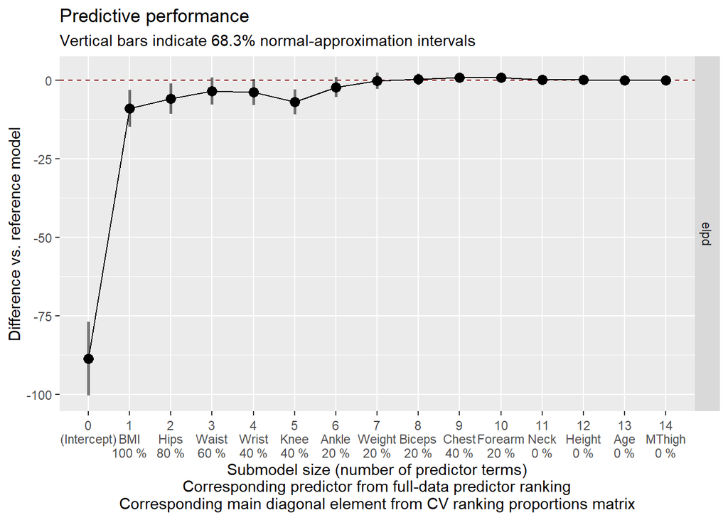

```r
set.seed(2341)
vs_cvf5 <- cv_varsel(object = ref_fit,  method = "forward",cv_method = "kfold",
  K = 5,validate_search = TRUE, verbose = FALSE)

save(vs_cvf5,file = file.path(PPath,"vs_cvs"))
#load(file = file.path(PPath,"vs_cvs"))

plot(vs_cvf5, deltas = TRUE, stats =  c('elpd'))
```

**Predictive Projections: L1 search,LOO (key results)**

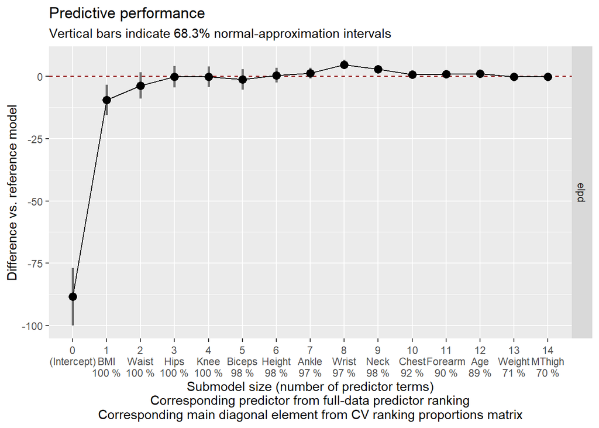

```r
# Generate model path: By varying lambda, a sequence of submodels with an increasing number of (non-zero) coefficients is created. ➤ The order in which coefficients “appear” serves as a ranking of the variables.

set.seed(2341)
vs_cvl <- cv_varsel(object = ref_fit, method = 'L1',  cv_method = 'loo', validate_search = TRUE, verbose = FALSE)

save(vs_cvl,file = file.path(PPath,"vs_cvl"))
#load(file = file.path(PPath,"vs_cvl"))

plot(vs_cvl, deltas = TRUE, stats =  c('elpd'))
```

**Predictive Projections: L1 search, 5-fold (internal robustness)**

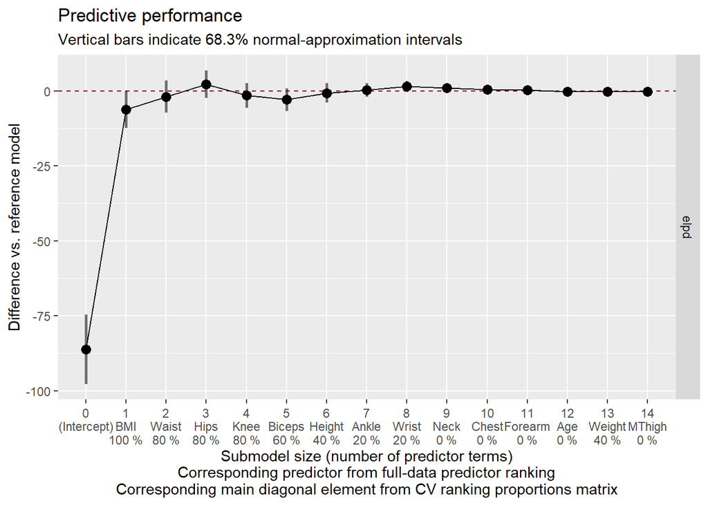

```r
set.seed(2341)
vs_cvl5 <- cv_varsel( object = ref_fit, method = 'L1',
  cv_method = "kfold",K = 5, verbose = FALSE)

save(vs_cvl5,file = file.path(PPath,"vs_cvl5"))
#load(file = file.path(PPath,"vs_cvl5"))

# Plot the variable selection

plot(vs_cvl5, deltas = TRUE, stats =  c('elpd'))
```

#### 1.2.1.1 Model stability: Stability of predictive projection

Forward Search (LOO)

```
 Summary of variable selection:

Family: gaussian
Link function: identity

Formula: Fat ~ Weight + Height + BMI + Age + Neck + Chest + Biceps + Hips +
    Waist + Forearm + MThigh + Wrist + Knee + Ankle
Observations: 184
Projection method: traditional
CV method: PSIS-LOO CV with search included (i.e., fold-wise searches)
Search method: forward
Maximum submodel size for the search: 14
Number of projected draws in the search: 20 (from clustered projection)
Number of projected draws in the performance evaluation: 400 (from clustered projection)
Argument `refit_prj`: TRUE

Submodel performance evaluation summary with `deltas = FALSE` and `cumulate = FALSE`:
 size ranking_fulldata cv_proportions_diag elpd elpd.se elpd.diff elpd.diff.se
    0      (Intercept)                  NA -585     9.1    -88.49        11.52
    1              BMI               1.000 -506     9.1     -9.36         6.09
    2             Hips               0.978 -503     9.2     -6.43         4.83
    3            Waist               0.870 -504     9.6     -7.37         4.02
    4            Wrist               0.886 -502    10.1     -5.39         3.47
    5             Knee               0.918 -504    10.3     -7.25         3.17
    6            Ankle               0.859 -500    10.5     -3.25         2.56
    7           Weight               0.870 -495     9.9      2.13         1.82
    8           Biceps               0.973 -495    10.1      1.78         1.46
    9            Chest               0.880 -497    10.2      0.39         1.29
   10          Forearm               0.908 -496    10.2      0.88         0.99
   11             Neck               0.875 -495    10.1      2.26         0.83
   12           Height               0.337 -498    10.4     -0.74         0.46
   13              Age               0.125 -498    10.5     -1.07         0.33
   14           MThigh               0.033 -497    10.4     -0.17         0.22

Reference model performance evaluation summary with `deltas = FALSE`:
   elpd elpd.se
   -497      10

️ Visualization of selection process:
```

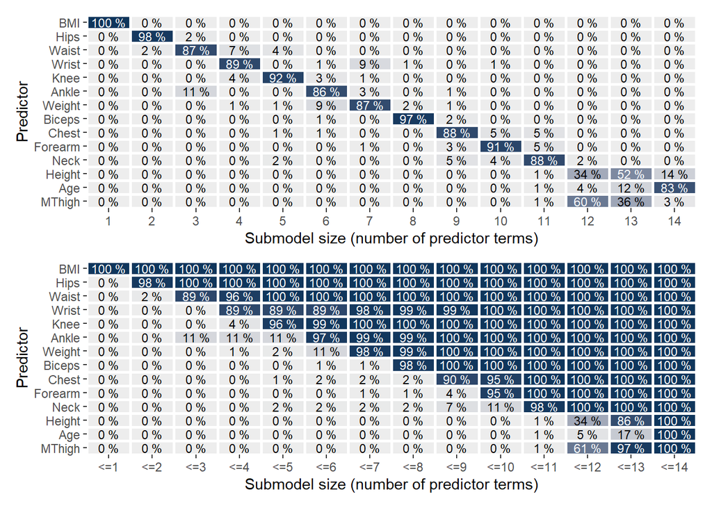

```
 Cumulative selection proportions (Top 5):
     predictor
size  BMI Hips Waist Wrist  Knee Ankle Weight Biceps Chest Forearm  Neck Height
  <=5   1    1     1 0.886 0.962 0.109  0.016      0 0.011       0 0.016      0
     predictor
size  Age MThigh
  <=5   0      0

 Suggested model size:
[1] 7

 Full ranking table:
 [1] "BMI"     "Hips"    "Waist"   "Wrist"   "Knee"    "Ankle"   "Weight"
 [8] "Biceps"  "Chest"   "Forearm" "Neck"    "Height"  "Age"     "MThigh"

 Terms selected (suggested size = 7):
[1] "BMI"    "Hips"   "Waist"  "Wrist"  "Knee"   "Ankle"  "Weight"

 Top 5 ranked terms:
[1] "BMI"   "Hips"  "Waist" "Wrist" "Knee"
```

```r
inspect_variable_selection(vs_cvf, top_n = 5)
```

Forward Search (5-fold)

```
 Summary of variable selection:

Family: gaussian
Link function: identity

Formula: Fat ~ Weight + Height + BMI + Age + Neck + Chest + Biceps + Hips +
    Waist + Forearm + MThigh + Wrist + Knee + Ankle
Observations: 184
Projection method: traditional
CV method: K-fold CV with K = 5 and search included (i.e., fold-wise searches)
Search method: forward
Maximum submodel size for the search: 14
Number of projected draws in the search: 20 (from clustered projection)
Number of projected draws in the performance evaluation: 400
Argument `refit_prj`: TRUE

Submodel performance evaluation summary with `deltas = FALSE` and `cumulate = FALSE`:
 size ranking_fulldata cv_proportions_diag elpd elpd.se elpd.diff elpd.diff.se
    0      (Intercept)                  NA -586     9.0   -88.642        11.68
    1              BMI                 1.0 -506     8.8    -9.019         5.84
    2             Hips                 0.8 -503     9.0    -5.886         4.77
    3            Waist                 0.6 -500     9.0    -3.464         4.29
    4            Wrist                 0.4 -501     9.2    -3.796         4.14
    5             Knee                 0.4 -504     9.9    -6.883         3.92
    6            Ankle                 0.2 -499     9.5    -2.162         3.13
    7           Weight                 0.2 -497     9.7    -0.188         2.58
    8           Biceps                 0.2 -497     9.9     0.281         1.76
    9            Chest                 0.4 -496     9.9     0.855         1.33
   10          Forearm                 0.2 -496    10.1     0.846         1.06
   11             Neck                 0.0 -497    10.2     0.221         0.58
   12           Height                 0.0 -497    10.3     0.177         0.53
   13              Age                 0.0 -497    10.3    -0.062         0.43
   14           MThigh                 0.0 -497    10.3     0.021         0.28

Reference model performance evaluation summary with `deltas = FALSE`:
   elpd elpd.se
   -497      10

️ Visualization of selection process:
```

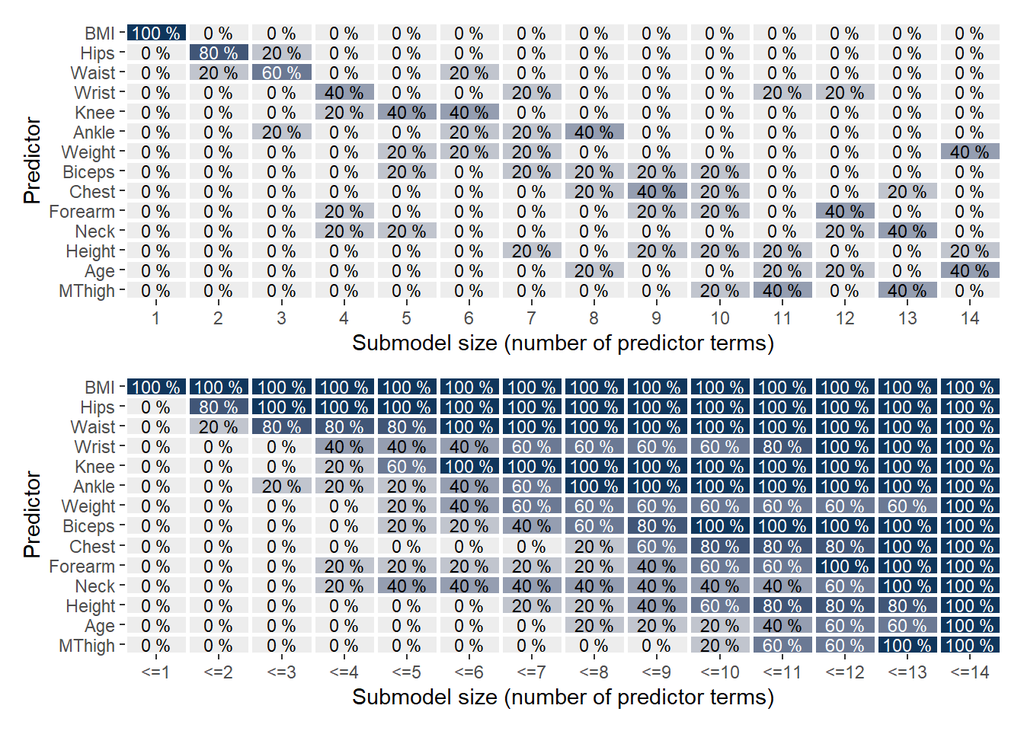

```
 Cumulative selection proportions (Top 5):
     predictor
size  BMI Hips Waist Wrist Knee Ankle Weight Biceps Chest Forearm Neck Height
  <=5   1    1   0.8   0.4  0.6   0.2    0.2    0.2     0     0.2  0.4      0
     predictor
size  Age MThigh
  <=5   0      0

 Suggested model size:
[1] 3

 Full ranking table:
 [1] "BMI"     "Hips"    "Waist"   "Wrist"   "Knee"    "Ankle"   "Weight"
 [8] "Biceps"  "Chest"   "Forearm" "Neck"    "Height"  "Age"     "MThigh"

 Terms selected (suggested size = 3):
[1] "BMI"   "Hips"  "Waist"

 Top 5 ranked terms:
[1] "BMI"   "Hips"  "Waist" "Wrist" "Knee"
```

```r
inspect_variable_selection(vs_cvf5, top_n = 5)
```

L1 Search (LOO)

```
 Summary of variable selection:

Family: gaussian
Link function: identity

Formula: Fat ~ Weight + Height + BMI + Age + Neck + Chest + Biceps + Hips +
    Waist + Forearm + MThigh + Wrist + Knee + Ankle
Observations: 184
Projection method: traditional
CV method: PSIS-LOO CV with search included (i.e., fold-wise searches)
Search method: L1
Maximum submodel size for the search: 14
Number of projected draws in the search: 1 (from clustered projection)
Number of projected draws in the performance evaluation: 400 (from clustered projection)
Argument `refit_prj`: TRUE

Submodel performance evaluation summary with `deltas = FALSE` and `cumulate = FALSE`:
 size ranking_fulldata cv_proportions_diag elpd elpd.se elpd.diff elpd.diff.se
    0      (Intercept)                  NA -585     9.1   -88.490        11.52
    1              BMI                1.00 -506     9.1    -9.362         6.09
    2            Waist                1.00 -501     8.6    -3.632         5.27
    3             Hips                1.00 -497     8.7    -0.106         4.26
    4             Knee                1.00 -497     8.7    -0.129         4.10
    5           Biceps                0.98 -498     8.8    -1.207         4.07
    6           Height                0.98 -496     9.6     0.475         2.97
    7            Ankle                0.97 -496    10.1     1.324         2.20
    8            Wrist                0.97 -492     9.7     4.782         1.91
    9             Neck                0.98 -494    10.0     2.881         1.35
   10            Chest                0.92 -496    10.3     0.831         1.08
   11          Forearm                0.90 -496    10.4     1.055         0.85
   12              Age                0.89 -496    10.4     1.222         0.79
   13           Weight                0.71 -497    10.5    -0.033         0.62
   14           MThigh                0.70 -497    10.4    -0.165         0.22

Reference model performance evaluation summary with `deltas = FALSE`:
   elpd elpd.se
   -497      10

️ Visualization of selection process:
```

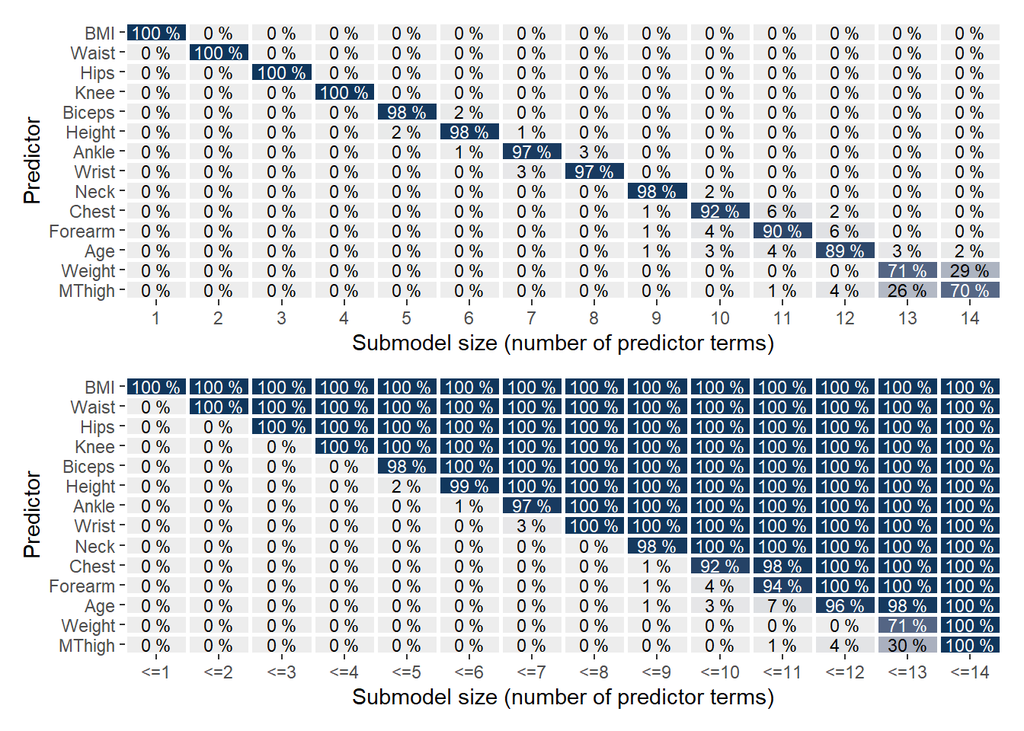

```
 Cumulative selection proportions (Top 5):
     predictor
size  BMI Waist Hips Knee Biceps Height Ankle Wrist Neck Chest Forearm Age
  <=5   1     1    1    1  0.984  0.016     0     0    0     0       0   0
     predictor
size  Weight MThigh
  <=5      0      0

 Suggested model size:
[1] 2

 Full ranking table:
 [1] "BMI"     "Waist"   "Hips"    "Knee"    "Biceps"  "Height"  "Ankle"
 [8] "Wrist"   "Neck"    "Chest"   "Forearm" "Age"     "Weight"  "MThigh"

 Terms selected (suggested size = 2):
[1] "BMI"   "Waist"

 Top 5 ranked terms:
[1] "BMI"    "Waist"  "Hips"   "Knee"   "Biceps"
```

```r
key_results <- inspect_variable_selection(vs_cvl, top_n = 5)
```

```r
solterms_final_fivel <- key_results$top_terms
```

L1 Search (5-fold)

```
 Summary of variable selection:

Family: gaussian
Link function: identity

Formula: Fat ~ Weight + Height + BMI + Age + Neck + Chest + Biceps + Hips +
    Waist + Forearm + MThigh + Wrist + Knee + Ankle
Observations: 184
Projection method: traditional
CV method: K-fold CV with K = 5 and search included (i.e., fold-wise searches)
Search method: L1
Maximum submodel size for the search: 14
Number of projected draws in the search: 1 (from clustered projection)
Number of projected draws in the performance evaluation: 400
Argument `refit_prj`: TRUE

Submodel performance evaluation summary with `deltas = FALSE` and `cumulate = FALSE`:
 size ranking_fulldata cv_proportions_diag elpd elpd.se elpd.diff elpd.diff.se
    0      (Intercept)                  NA -586     9.1    -86.22        11.52
    1              BMI                 1.0 -506     8.7     -6.19         6.09
    2            Waist                 0.8 -502     8.5     -1.92         5.39
    3             Hips                 0.8 -498     8.5      2.26         4.52
    4             Knee                 0.8 -501     9.2     -1.48         4.11
    5           Biceps                 0.6 -503     9.6     -2.93         3.82
    6           Height                 0.4 -501     9.6     -0.68         3.26
    7            Ankle                 0.2 -500     9.8      0.30         2.24
    8            Wrist                 0.2 -498     9.7      1.45         1.88
    9             Neck                 0.0 -499    10.1      0.93         1.43
   10            Chest                 0.0 -499    10.4      0.53         1.25
   11          Forearm                 0.0 -500    10.5      0.23         1.04
   12              Age                 0.0 -500    10.4     -0.21         0.82
   13           Weight                 0.4 -500    10.6     -0.19         0.53
   14           MThigh                 0.0 -500    10.5     -0.30         0.21

Reference model performance evaluation summary with `deltas = FALSE`:
   elpd elpd.se
   -500      10

️ Visualization of selection process:
```

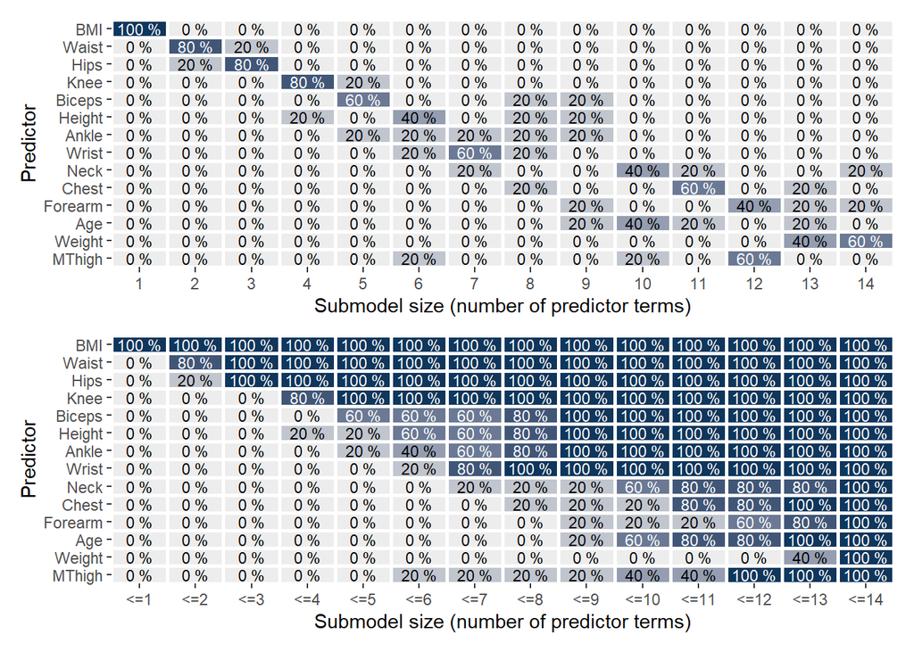

```
 Cumulative selection proportions (Top 5):
     predictor
size  BMI Waist Hips Knee Biceps Height Ankle Wrist Neck Chest Forearm Age
  <=5   1     1    1    1    0.6    0.2   0.2     0    0     0       0   0
     predictor
size  Weight MThigh
  <=5      0      0

 Suggested model size:
[1] 2

 Full ranking table:
 [1] "BMI"     "Waist"   "Hips"    "Knee"    "Biceps"  "Height"  "Ankle"
 [8] "Wrist"   "Neck"    "Chest"   "Forearm" "Age"     "Weight"  "MThigh"

 Terms selected (suggested size = 2):
[1] "BMI"   "Waist"

 Top 5 ranked terms:
[1] "BMI"    "Waist"  "Hips"   "Knee"   "Biceps"
```

```r
inspect_variable_selection(vs_cvl5, top_n = 5)
```

# 2 **Compute Projected Posterior: Post-selection-inference for L1 Search (LOO)**

Here post-selection inference starts, thus the results retain the uncertainty from the reference model posterior.

```r
# https://cran.r-project.org/web/packages/projpred/vignettes/projpred.html#post-selection-inference
proj_ref_fit <- project(vs_cvl, predictor_terms = solterms_final_fivel, ns = 4000)
```

#### 2.0.0.1 Model description

```r
# assemble data
results_beta <- matrix(0, nrow = 6 , ncol  = 5)
rownames(results_beta) <- c("(Intercept)",solterms_final_fivel)
colnames(results_beta) <- c("Regression coefficient", "Standardized beta", "Cum. proportions <=5", "5% PD-quantile", "95% PD-quantile")

mat <- as.matrix(proj_ref_fit)
beta <- mat[, 1:(ncol(mat) - 1)]

# Transform matrix to draws format (optional, for posterior-friendly summaries)
draws1 <- posterior::as_draws_matrix(beta)

summary_tbl <- summarise_draws(draws1, mean,  median, ~ quantile(.x, probs = c(0.05, 0.95)))
# Compute standard deviations (excluding the first two columns) for women dataset
sd_women <- apply(women[, -c(1,2)], 2, sd)
vars_to_select <- c("BMI", "Waist", "Hips", "Knee", "Biceps")
sd_selected <- sd_women[intersect(vars_to_select, names(sd_women))]

std_coef <- summary_tbl$mean[2:6] * (sd_selected)
std_coef <- c(summary_tbl$mean[1],std_coef )

results_beta[,1] <- round(summary_tbl$mean,3)
results_beta[,2] <- round(std_coef,3)
results_beta[,3] <- round(c(1.0,key_results$cumprop[1:5]),3)
results_beta[,4] <- round(summary_tbl$`5%`,3)
results_beta[,5] <- round(summary_tbl$`95%`,3)


results_beta<-results_beta[order(-abs(results_beta[,3])),]
kable(results_beta, format="html", caption="Regression coefficients and stability measures")
```

Regression coefficients and stability measures

|  | Regression coefficient | Standardized beta | Cum. proportions <=5 | 5% PD-quantile | 95% PD-quantile |
| --- | --- | --- | --- | --- | --- |
| (Intercept) | -36.082 | -36.082 | 1.000 | -44.038 | -28.228 |
| BMI | 0.721 | 1.945 | 1.000 | 0.362 | 1.075 |
| Waist | 0.210 | 1.348 | 1.000 | 0.081 | 0.346 |
| Hips | 0.164 | 1.003 | 1.000 | 0.024 | 0.302 |
| Knee | 0.259 | 0.560 | 1.000 | -0.045 | 0.577 |
| Biceps | 0.097 | 0.238 | 0.984 | -0.185 | 0.380 |

Global model descriptors:

```r
y_linpred_female <- proj_linpred(proj_ref_fit, newdata = women)
women2 <- cbind(women, linpred = colMeans(y_linpred_female$pred))
R.square <- (cor(women2$linpred, women2$Fat, method = "pearson"))^2
#R.square

draws1b <- posterior::as_draws_matrix(mat)

summary_tbl_1b <- summarise_draws(draws1b, mean,  median, ~ quantile(.x, probs = c(0.05, 0.95)))
summary_sigma <- summary_tbl_1b %>% slice(7)
sigma_mean <- summary_sigma %>% pull(mean)

global_desc <- c(residual_error = round(sigma_mean,3) , Rsq = round(R.square,3))
names(global_desc) <- c("Residual error",  "R-squared ")

kable(global_desc, caption="Global model descriptors")
```

Global model descriptors

|  | x |
| --- | --- |
| Residual error | 3.704 |
| R-squared | 0.638 |

```r
kable(summary_sigma , digits = 3, caption = "Residual Error ") %>%
  kable_styling(full_width = FALSE)
```

Residual Error

| variable | mean | median | 5% | 95% |
| --- | --- | --- | --- | --- |
| sigma | 3.704 | 3.703 | 3.376 | 4.039 |

```r
r2_values  <- bayes_r2(ypred = y_linpred_female$pred, y = women2$Fat)

summary_r2 <- data.frame(
  mean   = round(mean(r2_values),3),
  median = round(median(r2_values),3),
  p05   = round(quantile(r2_values, 0.05),3),
  p95   = round(quantile(r2_values, 0.95),3)
)
#colnames(summary_r2)
rownames(summary_r2) <- "R²"
colnames(summary_r2)[colnames(summary_r2) == "p05" ] <- "5%"
colnames(summary_r2)[colnames(summary_r2) ==  "p95" ] <- "95%"

kable(summary_r2 ,digits = 3 , caption = "R² as defined by Gelman et al. (2019)") %>%
  kable_styling(full_width = FALSE)
```

R² as defined by Gelman et al. (2019)

|  | mean | median | 5% | 95% |
| --- | --- | --- | --- | --- |
| R² | 0.636 | 0.638 | 0.592 | 0.672 |

#### 2.0.0.2 Assumptions and diagnostics: residual analysis

```r
print("Five active predictors")
```

```
[1] "Five active predictors"
```

```r
active_predictors <- solterms_final_fivel
active_predictors
```

```
[1] "BMI"    "Waist"  "Hips"   "Knee"   "Biceps"
```

```r
print("Eight ext. active predictors")
```

```
[1] "Eight ext. active predictors"
```

```r
active_predictors_ext <- key_results$full_ranking[1:8]
active_predictors_ext
```

```
[1] "BMI"    "Waist"  "Hips"   "Knee"   "Biceps" "Height" "Ankle"  "Wrist"
```

```r
p <- length(predictors)

x <- as.matrix(women[, predictors])
y <- as.numeric(women$Fat)
n <- nrow(x)
```

```r
library(ggplot2)

predictions <- women2$linpred
y <- women2$Fat
# Compute residuals
prj_predictW <- proj_predict(proj_ref_fit)

qres.m1 = createDHARMa(simulatedResponse = t(prj_predictW),
                          observedResponse = women2$Fat,
                          fittedPredictedResponse = apply(prj_predictW, 2, median), integerResponse = F, seed = 123, method = "PIT")
# uniform distributed residuals
print("Uniform residuals")
```

```
[1] "Uniform residuals"
```

```r
summary(residuals(qres.m1))
```

```
   Min. 1st Qu.  Median    Mean 3rd Qu.    Max.
 0.0025  0.2644  0.4913  0.4968  0.7212  0.9975
```

```r
# transform to normal scale
residuals <- qnorm(residuals(qres.m1))
print("Normal residuals")
```

```
[1] "Normal residuals"
```

```r
summary(residuals)
```

```
     Min.   1st Qu.    Median      Mean   3rd Qu.      Max.
-2.807034 -0.629919 -0.021935 -0.003763  0.586571  2.807034
```

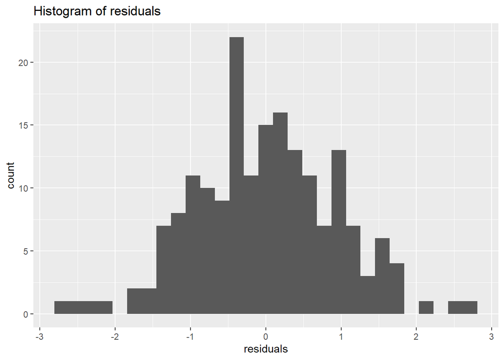

```r
ggplot(data=data.frame(residuals), aes(x=residuals)) + geom_histogram() + ggtitle(label="Histogram of residuals")
```

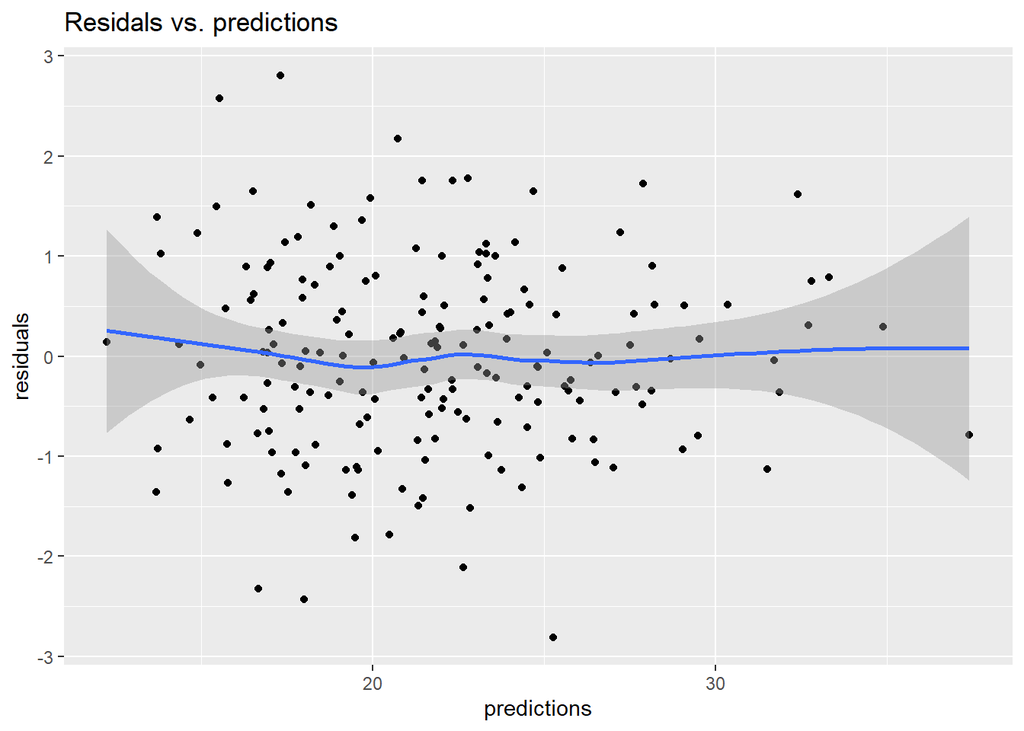

```r
sqrt_abs_res <- sqrt(abs(residuals))

ggplot(data=data.frame(residuals, predictions, y), aes(x=predictions, y=residuals)) + geom_point() + geom_smooth() + ggtitle(label="Residals vs. predictions")
```

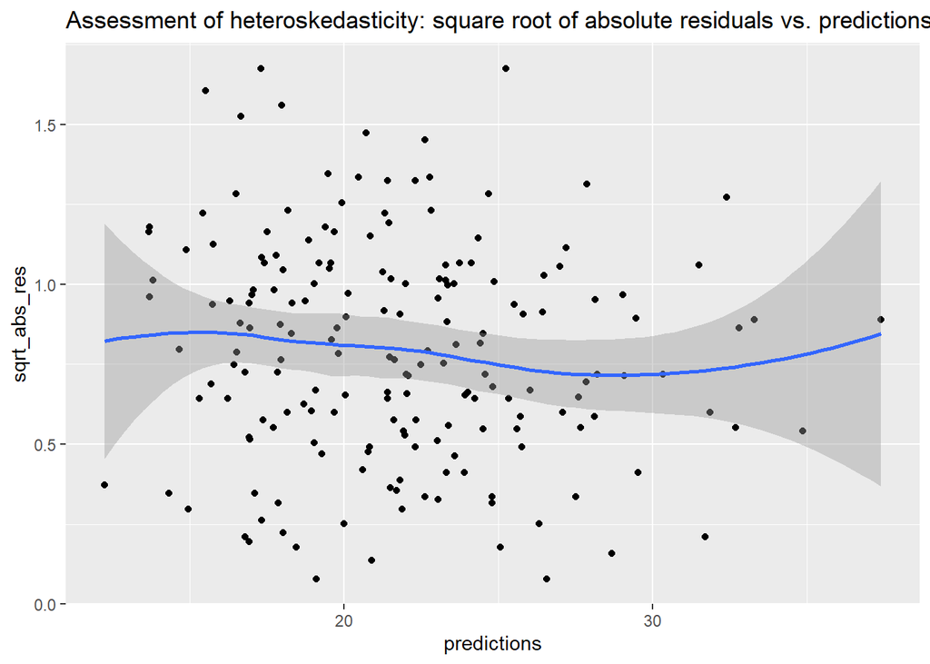

```r
ggplot(data=data.frame(sqrt_abs_res, predictions, y), aes(x=predictions, y=sqrt_abs_res)) + geom_point() + geom_smooth() + ggtitle(label="Assessment of heteroskedasticity: square root of absolute residuals vs. predictions")
```

In the following residual plots, the nearly-selected predictors are denoted by red dots, the selected predictors by blue dots.

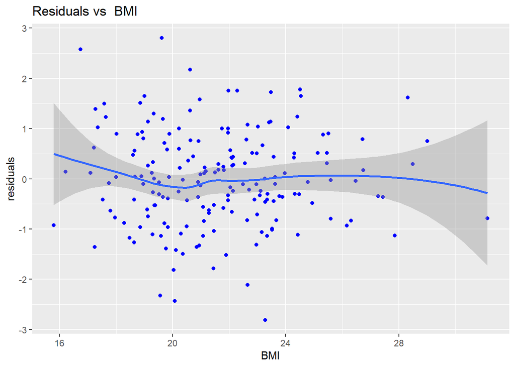

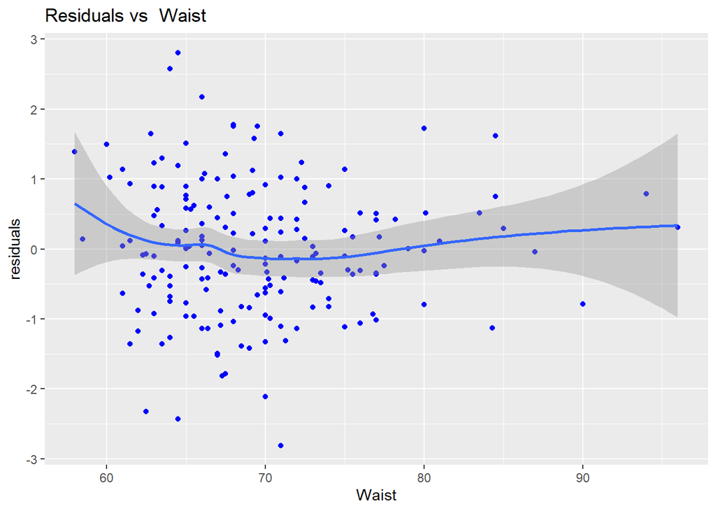

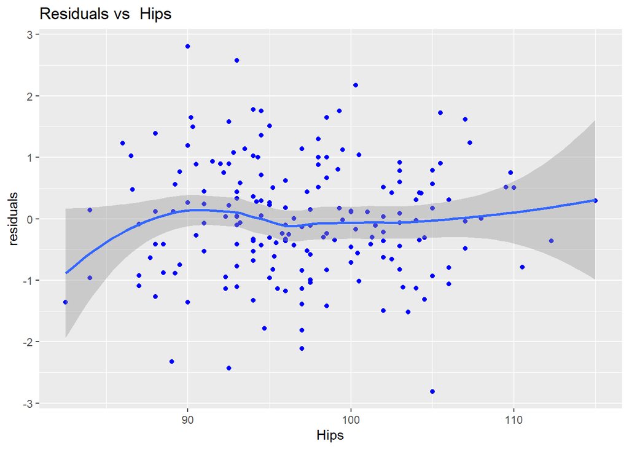

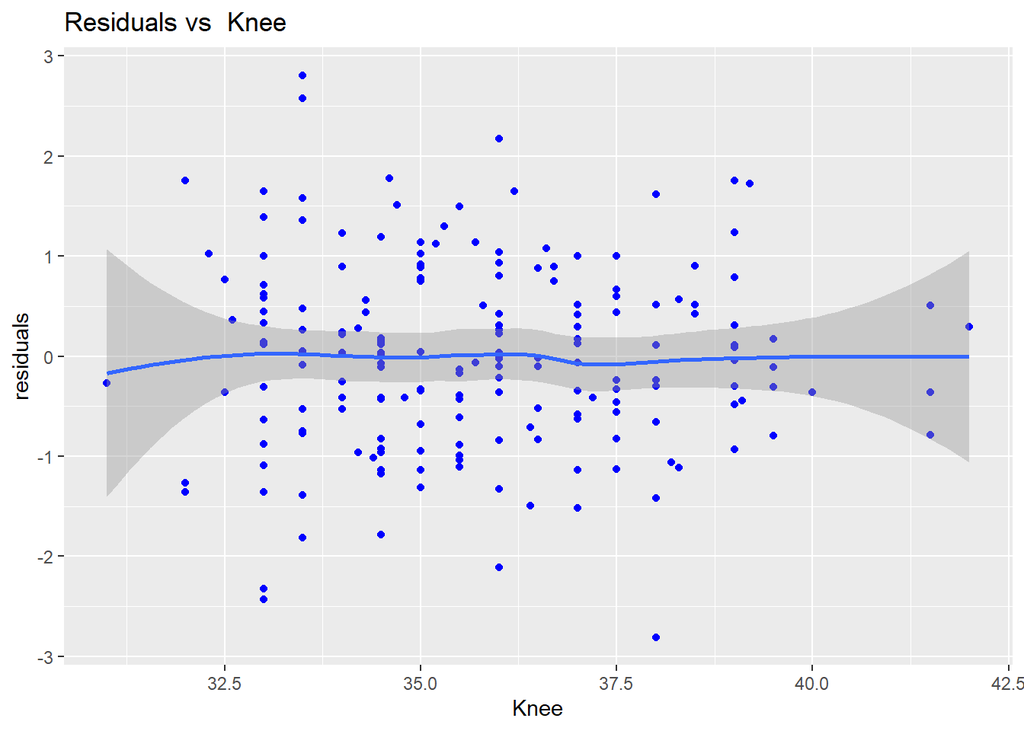

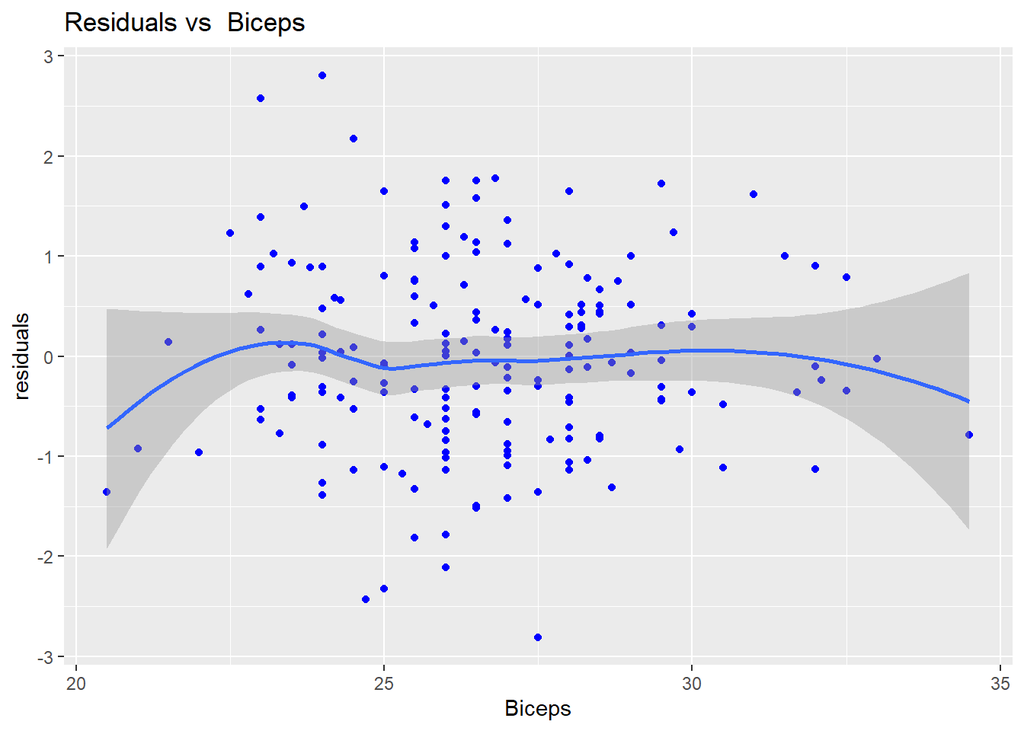

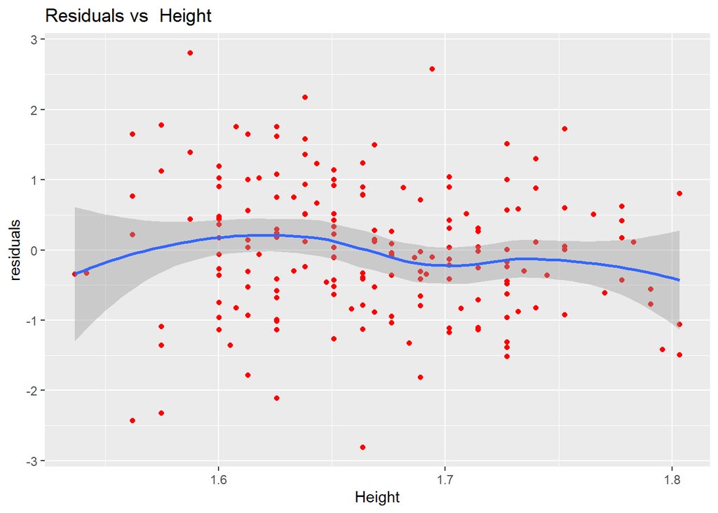

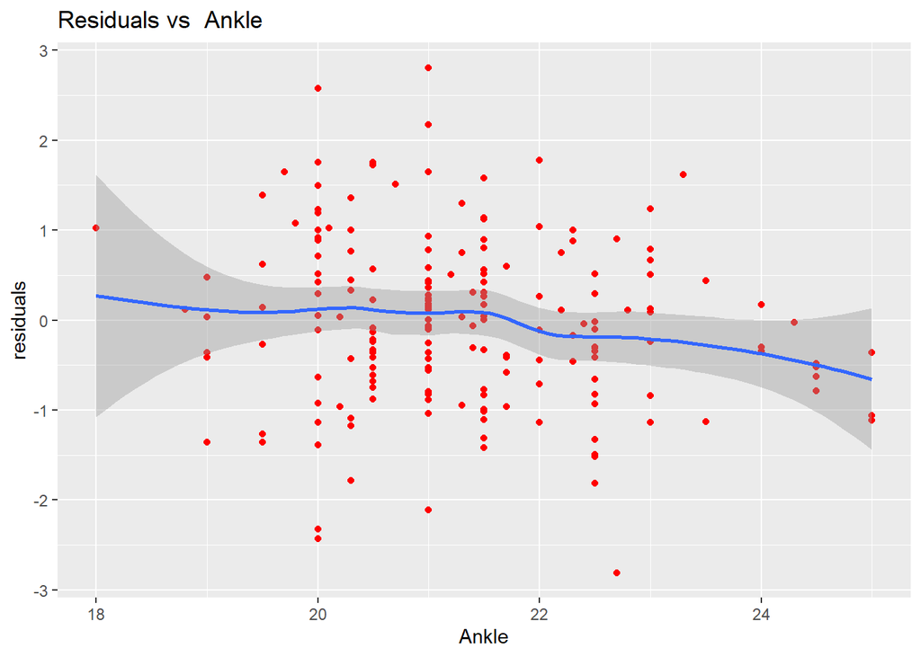

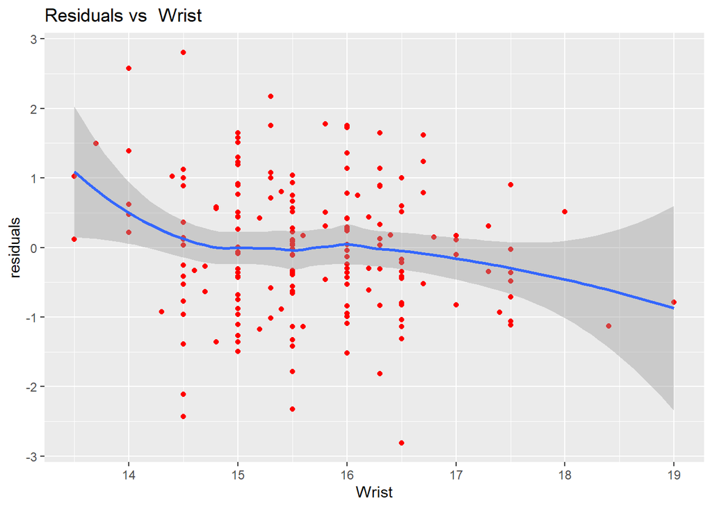

```r
for(v in active_predictors_ext){
  cols=ifelse(v %in% active_predictors, "blue", "red")
  print(ggplot(data=data.frame(residuals, variable=x[,v]), aes(x=variable, y=residuals), xlab(v)) + geom_point(color=cols) + geom_smooth() + xlab(v) + ggtitle(label=paste("Residuals vs ",v, collapse="")))
  }
```

### 2.0.1 Objective 2: Model validation

```r
# Computing predictions in the men's data set

xmen <- as.matrix(men[, predictors])
ymen <- as.numeric(men$Fat)
ymean_men <- mean(ymen)
nmen <- nrow(xmen)

y_linpred_male <- proj_linpred(proj_ref_fit,  newdata = men)
ypred_men <- colMeans(y_linpred_male$pred)
res_men <- ymen - ypred_men

r2_val <- 1 - sum((ymen - ypred_men)^2)/sum((ymen - ymean_men)^2)
R.squareM <- (cor(ypred_men,ymen, method = "pearson"))^2



rmspe <- sqrt(mean(res_men^2))

glob_pm <- c(r2_val, rmspe,R.squareM)
names(glob_pm) <- c("Validation R-squared", "Root mean squared prediction error", "R-squared")

kable(glob_pm, caption="Overall performance measures")
```

Overall performance measures

|  | x |
| --- | --- |
| Validation R-squared | -1.4886814 |
| Root mean squared prediction error | 13.1955366 |
| R-squared | 0.5648823 |

```r
r2_values_men  <- bayes_r2(ypred = y_linpred_male$pred, y = men$Fat)

summary_r2_men  <- data.frame(
  mean   = round(mean(r2_values_men),3),
  median = round(median(r2_values_men),3),
  p05   = round(quantile(r2_values_men, 0.05),3),
  p95   = round(quantile(r2_values_men, 0.95),3)
)

rownames(summary_r2_men) <- "R²"
colnames(summary_r2_men)[colnames(summary_r2_men) == "p05" ] <- "5%"
colnames(summary_r2_men)[colnames(summary_r2_men) ==  "p95" ] <- "95%"

kable(summary_r2_men  ,digits = 3 , caption = "R² as defined by Gelman et al. (2019) for men") %>%
  kable_styling(full_width = FALSE)
```

R² as defined by Gelman et al. (2019) for men

|  | mean | median | 5% | 95% |
| --- | --- | --- | --- | --- |
| R² | 0.583 | 0.589 | 0.505 | 0.642 |

```r
r2_values_men_ext  <- bayes_r2_ext(ypred = y_linpred_male$pred, y = men$Fat)


summary_r2_men_ext  <- data.frame(
  mean   = round(mean(r2_values_men_ext),3),
  median = round(median(r2_values_men_ext),3),
  p05   = round(quantile(r2_values_men_ext, 0.05),3),
  p95   = round(quantile(r2_values_men_ext, 0.95),3)
)

rownames(summary_r2_men_ext) <- "R²"
colnames(summary_r2_men_ext)[colnames(summary_r2_men_ext) == "p05" ] <- "5%"
colnames(summary_r2_men_ext)[colnames(summary_r2_men_ext) ==  "p95" ] <- "95%"

kable(summary_r2_men_ext  ,digits = 3 , caption = "Validation R²  for men") %>%
  kable_styling(full_width = FALSE)
```

Validation R² for men

|  | mean | median | 5% | 95% |
| --- | --- | --- | --- | --- |
| R² | -1.527 | -1.507 | -2.36 | -0.758 |

Calibration plot:

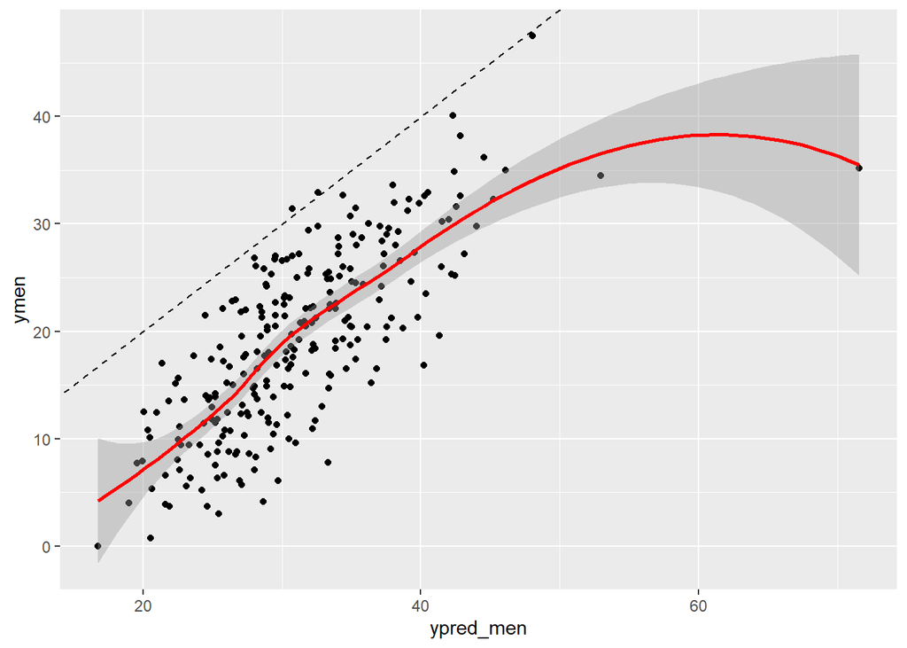

```r
# Calibration plot

ggplot(data.frame(ypred_men, ymen), aes(x=ypred_men, y=ymen)) + geom_point() + geom_smooth(col="red") + geom_abline(intercept=0, slope=1, linetype="dashed")
```

Calibration model:

```r
observed <- men$Fat
predicted <- ypred_men
calib_data <- data.frame(observed = observed, predicted = predicted)
# Compute calibration intercept and slope
calibration_model <- stan_glm(observed ~ predicted, family = gaussian(), data = calib_data)
calibration_model0 <- stan_glm(observed ~ offset(predicted), family = gaussian(), data = calib_data)
```

```r
summary(calibration_model)
```

```
Model Info:
 function:     stan_glm
 family:       gaussian [identity]
 formula:      observed ~ predicted
 algorithm:    sampling
 sample:       4000 (posterior sample size)
 priors:       see help('prior_summary')
 observations: 252
 predictors:   2

Estimates:
              mean   sd    10%   50%   90%
(Intercept) -10.6    1.7 -12.8 -10.6  -8.4
predicted     1.0    0.1   0.9   1.0   1.0
sigma         5.6    0.2   5.3   5.6   5.9

Fit Diagnostics:
           mean   sd   10%   50%   90%
mean_PPD 19.2    0.5 18.5  19.2  19.8

The mean_ppd is the sample average posterior predictive distribution of the outcome variable (for details see help('summary.stanreg')).

MCMC diagnostics
              mcse Rhat n_eff
(Intercept)   0.0  1.0  3923
predicted     0.0  1.0  3914
sigma         0.0  1.0  3775
mean_PPD      0.0  1.0  3692
log-posterior 0.0  1.0  1873

For each parameter, mcse is Monte Carlo standard error, n_eff is a crude measure of effective sample size, and Rhat is the potential scale reduction factor on split chains (at convergence Rhat=1).
```

```r
summary(calibration_model0)
```

```
Model Info:
 function:     stan_glm
 family:       gaussian [identity]
 formula:      observed ~ offset(predicted)
 algorithm:    sampling
 sample:       4000 (posterior sample size)
 priors:       see help('prior_summary')
 observations: 252
 predictors:   1

Estimates:
              mean   sd    10%   50%   90%
(Intercept) -12.0    0.4 -12.4 -12.0 -11.5
sigma         5.6    0.2   5.2   5.5   5.9

Fit Diagnostics:
           mean   sd   10%   50%   90%
mean_PPD 19.2    0.5 18.5  19.2  19.8

The mean_ppd is the sample average posterior predictive distribution of the outcome variable (for details see help('summary.stanreg')).

MCMC diagnostics
              mcse Rhat n_eff
(Intercept)   0.0  1.0  2481
sigma         0.0  1.0  2931
mean_PPD      0.0  1.0  2895
log-posterior 0.0  1.0  1454

For each parameter, mcse is Monte Carlo standard error, n_eff is a crude measure of effective sample size, and Rhat is the potential scale reduction factor on split chains (at convergence Rhat=1).
```

```r
posterior_samples <- as.matrix(calibration_model)
posterior_samples0 <- as.matrix(calibration_model0)
intercepts <- posterior_samples0[, "(Intercept)"]
slopes <- posterior_samples[, "predicted"]

cal_slope <- mean(slopes)
conf_slope <- quantile(posterior_samples[, "predicted"], probs = c(0.025,  0.975))
cal_int <- mean(intercepts)
conf_int <- quantile(posterior_samples0[, "(Intercept)"], probs = c(0.025,  0.975))

cal_stats <- c(cal_int, conf_int, cal_slope, conf_slope)

names(cal_stats) <- c("Calibration intercept", "Calibration intercept, lower 95% PD", "Calibration intercept, upper 95% PD", "Calibration slope", "Calibration slope, lower 95% PD", "Calibration slope, upper 95% PD")

kable(cal_stats, caption="Calibration statistics")
```

Calibration statistics

|  | x |
| --- | --- |
| Calibration intercept | -11.9870878 |
| Calibration intercept, lower 95% PD | -12.6880499 |
| Calibration intercept, upper 95% PD | -11.2912557 |
| Calibration slope | 0.9547744 |
| Calibration slope, lower 95% PD | 0.8503627 |
| Calibration slope, upper 95% PD | 1.0607484 |

```r
# Dataframe  for regression lines
regression_lines <- data.frame(
  intercept = intercepts,
  slope = slopes
)

n_lines <- nrow(as.matrix(calibration_model))
print(n_lines)
```

```
[1] 4000
```

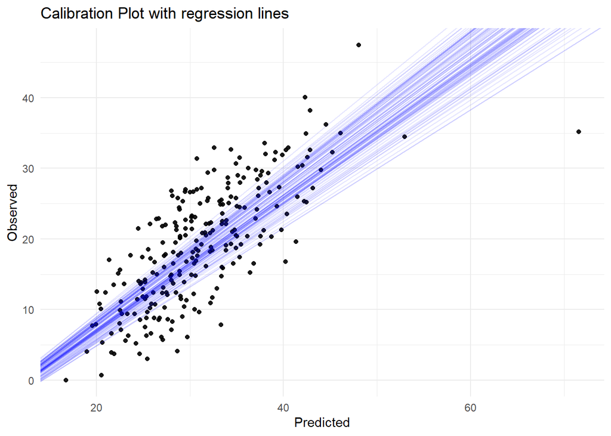

```r
sampled_lines <- regression_lines[sample(nrow(regression_lines), size = 100), ]
# plot
ggplot(calib_data, aes(x = predicted, y = observed)) +
  geom_point(alpha = 0.9) +
  geom_abline(data = sampled_lines, aes(intercept = intercept, slope = slope), alpha = 0.1, color = "blue") +
  labs(title = "Calibration Plot with regression lines",
       x = "Predicted",
       y = "Observed") +
  theme_minimal()
```

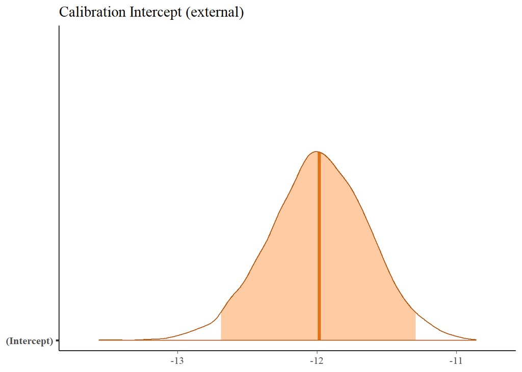

```r
color_scheme_set("orange")


# Intercept
mcmc_areas(
  as.matrix(calibration_model0),
  pars = "(Intercept)",
  prob = 0.95
) +
  ggtitle("Calibration Intercept (external)")
```

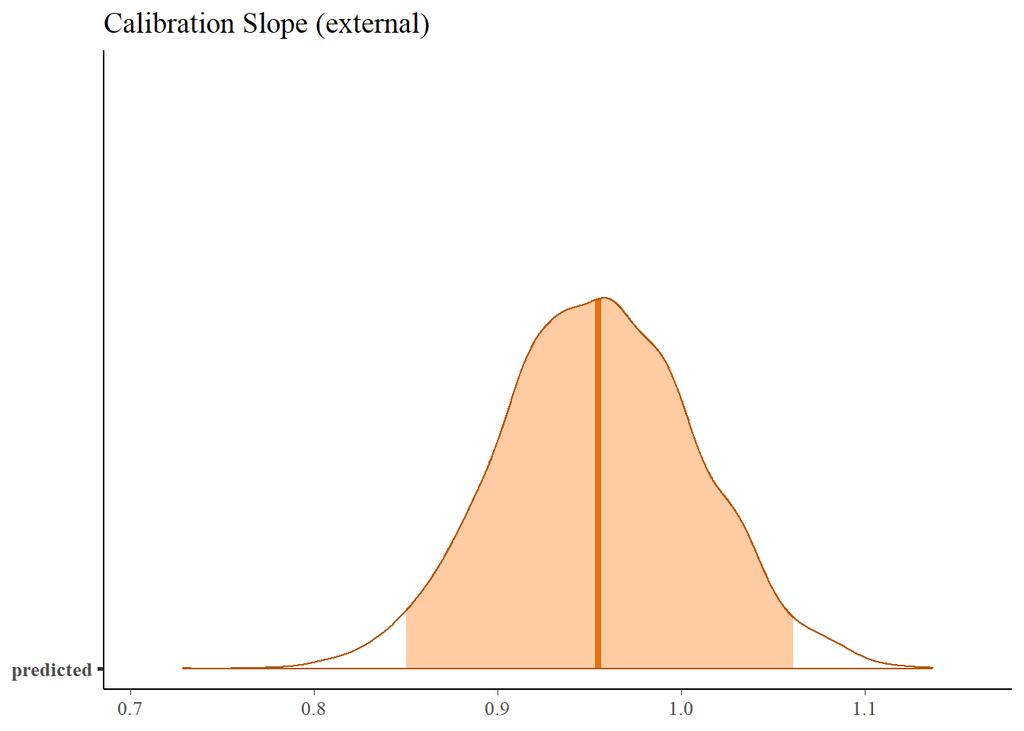

```r
# Slope
mcmc_areas(
  as.matrix(calibration_model),
  pars = "predicted",
  prob = 0.95
) +
  ggtitle("Calibration Slope (external)")
```

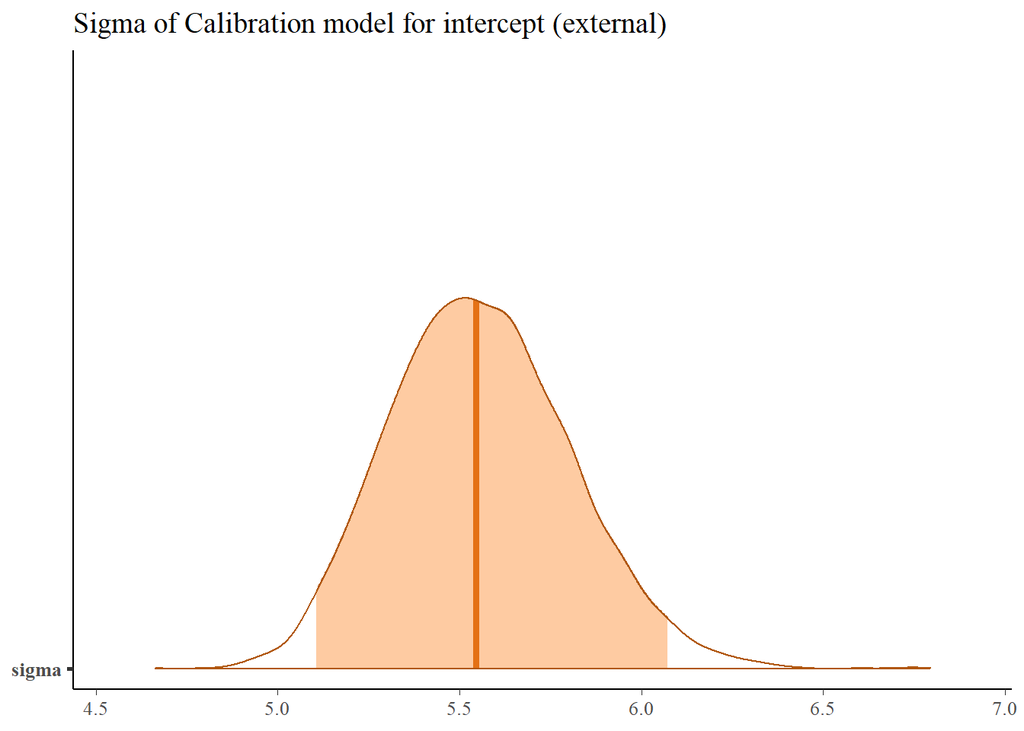

```r
mcmc_areas(as.matrix(calibration_model0),
           pars = "sigma",
           prob = 0.95) +
  ggtitle("Sigma of Calibration model for intercept (external)")
```

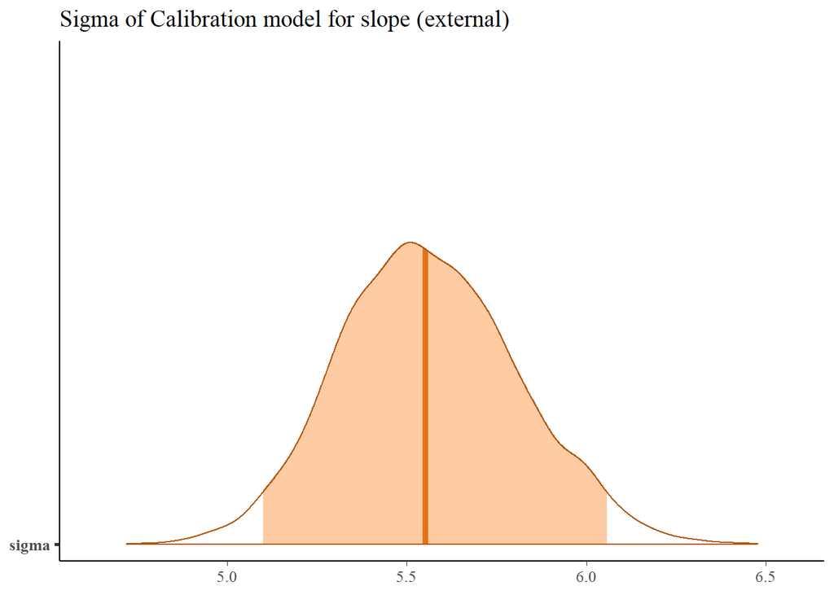

```r
mcmc_areas(as.matrix(calibration_model),
           pars = "sigma",
           prob = 0.95) +
  ggtitle("Sigma of Calibration model for slope (external)")
```

```r
r2_values_men_extK  <- bayes_r2_ext(ypred = y_linpred_male$pred + intercepts, y = men$Fat)


summary_r2_men_extK  <- data.frame(
  mean   = round(mean(r2_values_men_extK),3),
  median = round(median(r2_values_men_extK),3),
  p05   = round(quantile(r2_values_men_extK, 0.05),3),
  p95   = round(quantile(r2_values_men_extK, 0.95),3)
)

rownames(summary_r2_men_extK) <- "R²"
colnames(summary_r2_men_extK)[colnames(summary_r2_men_extK) == "p05" ] <- "5%"
colnames(summary_r2_men_extK)[colnames(summary_r2_men_extK) ==  "p95" ] <- "95%"

kable(summary_r2_men_extK, digits = 3 , caption = "Cor. Validation R²  for men") %>%
  kable_styling(full_width = FALSE)
```

Cor. Validation R² for men

|  | mean | median | 5% | 95% |
| --- | --- | --- | --- | --- |
| R² | 0.523 | 0.538 | 0.419 | 0.58 |

The calibration slope is approximately 1.0, exactly 0.9547744, suggesting good predictive scaling. However, the intercept indicates a systematic overestimation of body fat in men by 11.9870878 percentage points.

To address this bias, a re-calibrated model adjusting the intercept by -11.9870878. could be proposed. This adjusted model yields an apparent ( R^2 ) of 0.523. The uncertainty of the ( R^2 )estimate is expressed through a posterior predictive interval, reflecting the range of plausible values based on the model and the observed data.